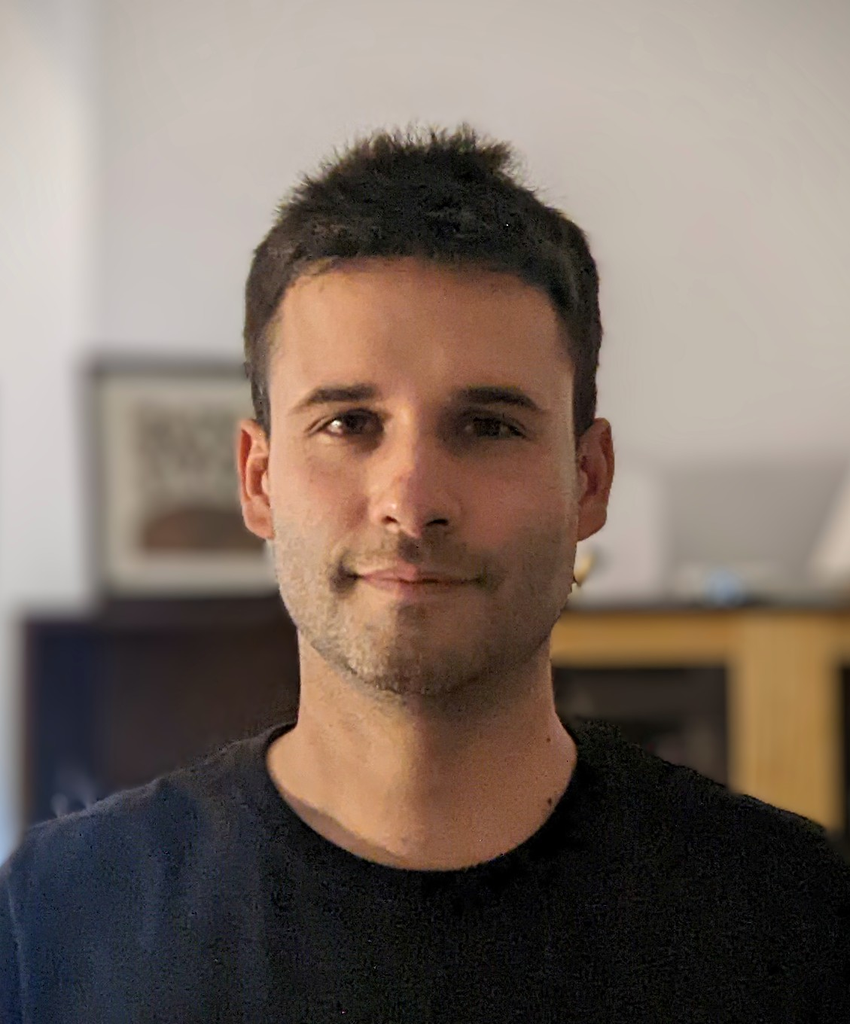

# Nicolas Robinson-Garcia

## Prácticas extracurriculares en U-CHASS

Ofertamos 2 contratos de 6 meses para trabajar con nosotros en la Unidad de Excelencia de Ciencias Sociales y Humanas Computacionales (U-CHASS) de reciente creación. Únete a un equipo de trabajo multidisciplinar formada por investigadores de las áreas de Ciencias de la Computación, Documentación, Comunicaciíon Audiovisual, Filología y Literatura Inglesa e Historia Contemporánea y de la Ciencia e iníciate en el mundo de la investigación.

**El plazo de solicitud de los contratos abre en Febrero de 2024.**

### Perfil Ciencias Sociales / Humanidades

**Descripción.** Introducción a la investigación en Linguística Computacional y Humanidades Digitales. La persona contratada realizará labores de apoyo a la investigación y la gestión de la Unidad de Excelencia U-CHASS (Unit for Computational Humanities And Social Sciences). Será un miembro más de un equipo multidisciplinar e internacional de investigadores tanto de la Universidad de Granada como de otros centros nacionales e internacionales. Dentro de sus actividades se incluirán tareas tales como gestión y organización de reuniones y eventos académicos y científicos, trabajo de campo en la obtención y procesamiento de datos de investigaciíon y coordinación de tareas de comunicación tanto interna como externa de la Unidad.

**Retribución/mes.** 400€

**Fecha de inicio y final.** 1/03/2024 - 31/08/2024 (6 meses)

**Estudios.** Aceptamos candidatos cursando cualquiera de los siguientes estudios:

- Grado en Traducción e Interpretación
- Grado en Comunicación Audiovisual
- Grado en Historia
- Grado en Información y Documentación
- Grado en Lenguas Modernas y sus Literaturas
- Máster Universitario en Cultura de Paz, Conflictos, Educación y Derechos Humanos
- Máster Universitario en Información y Comunicación Científica
- Máster Universitario en Nuevos Medios Interactivos y Periodismo Multimedia
- Máster Universitario en Lenguas y Culturas Modernas
- Máster Universitario en Información Científica: Tratamiento, Acceso y Evaluación
- Máster Universitario en Traducción E Interpretación
- Doble Grado en Traducción e Interpretación y Turismo
- Máster Universitario en Lógica y Filosofía de la Ciencia
- Máster Universitario en Estudios de Las Mujeres y de Género

**Solicitud.** A través de la [plataforma ÍCARO](https://ugr.portalicaro.es/), Oferta código 400407

### Perfil Ciencias de la Computación

**Retribución/mes.** 400€

**Fecha de inicio y final.** 1/03/2024 - 31/08/2024 (6 meses)

**Estudios.** Aceptamos candidatos cursando cualquiera de los siguientes estudios:

- Grado en Ingeniería Informática
- PCEO Grado en Ingeniería Informática / Grado en Matemáticas
- Doble Grado en Administración y Dirección de Empresas e Informática
- Máster Universitario en Ciencia de Datos e Ingeniería de Computadores
- Máster Universitario en Ingeniería Informática

**Solicitud.** A través de la [plataforma ÍCARO](https://ugr.portalicaro.es/), Oferta código 400488